# Final Assignment

May 3, 2017

```r
library(tidytext)
library(dplyr)
library(wordcloud2)
library(ggplot2)
library(readr)
library(car)
```

```r
warren <- read_csv("https://raw.githubusercontent.com/ryanburge/pls2003_sp17/master/twitter/warren.csv")
ryan <- read_csv("https://raw.githubusercontent.com/ryanburge/pls2003_sp17/master/twitter/paulryan.csv")
```

Exercise 1:

You have just loaded the Elizabeth Warren and Paul Ryan tweets datasets.

First, I want you to put each word in the twitter accounts into it’s own line.

Then, do a word count.

Then, clean up all the “stop words” for each account.

Then, show me a wordcloud of each.

```r
tidy <- warren %>% unnest_tokens(word, text)
tidy <- tidy %>% count(word, sort = TRUE)
tidy <- tidy %>% anti_join(stop_words)

wordcloud2(tidy)
```

[interactive chart not shown]

```r
tidy2 <- ryan %>% unnest_tokens(word, text)
tidy2 <- tidy2 %>% count(word, sort = TRUE)
tidy2 <- tidy2 %>% anti_join(stop_words)

wordcloud2(tidy2)
```

[interactive chart not shown]

Finally, I want you to do a sentiment score for their overall Twitter accounts. Use the “afinn” lexicon to do so.

If you do this all in two total lines of code, I will get you 10 additional bonus points.

Hint: three pipes, mutate, summarize.

```r
tidy %>% inner_join(get_sentiments("afinn")) %>% mutate(total = score *n) %>% summarise(sum = sum(total))
```

```
## # A tibble: 1 × 1
##     sum
##   <int>
## 1  -380
```

```r
tidy2 %>% inner_join(get_sentiments("afinn")) %>% mutate(total = score *n) %>% summarise(sum = sum(total))
```

```
## # A tibble: 1 × 1
##     sum
##   <int>
## 1    72
```

Who has the more positive account, overall? Paul Ryan or Elizabeth Warren? Why do you think that is?

Exercise 2

```r
prayer <- read_csv("https://raw.githubusercontent.com/ryanburge/prayer_breakfast/master/prayer_breakfast.csv")
```

I want you to use ggplot2 to give me a histogram of the most frequently used words in the speech for the Republican and the Democrat.

Make sure to clean up the stop words first!

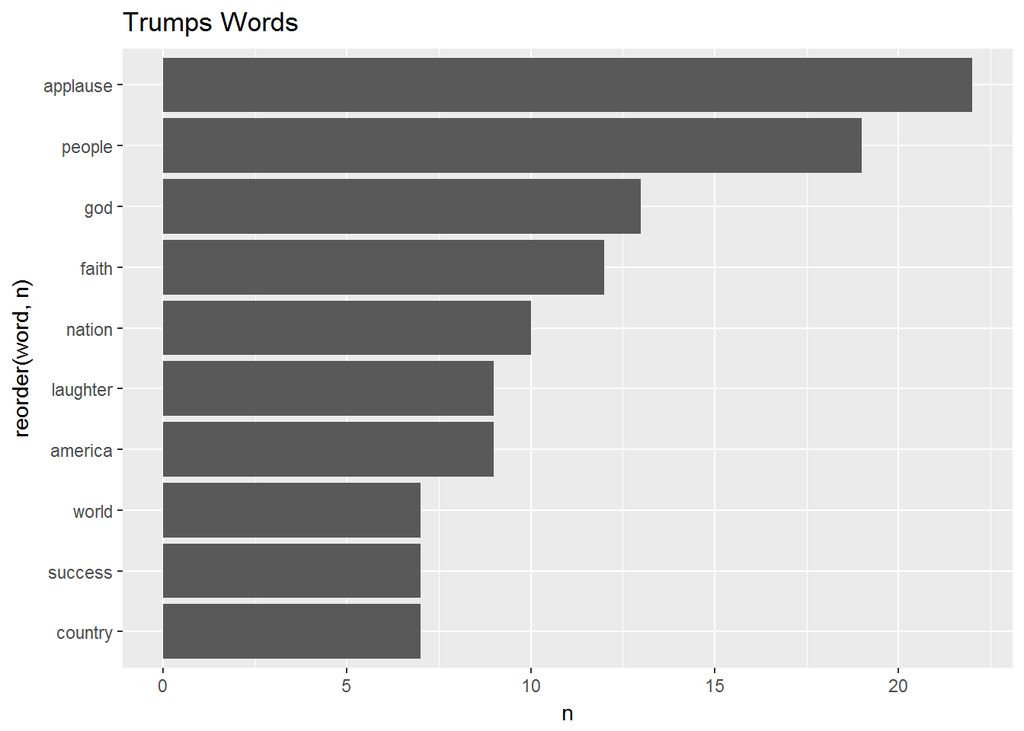

```r
trump <- prayer[1,]
obama <- prayer[2,]


tidy3 <- trump %>% unnest_tokens(word, text)
tidy3 <- tidy3 %>% count(word, sort = TRUE)
tidy3 <- tidy3 %>% anti_join(stop_words)

tidy4 <- obama %>% unnest_tokens(word, text)
tidy4 <- tidy4 %>% count(word, sort = TRUE)
tidy4 <- tidy4 %>% anti_join(stop_words)


ggplot(tidy3 %>% filter(n >= 7), aes(x=reorder(word, n), y=n)) +geom_col() + coord_flip() + ggtitle("Trumps Words")
```

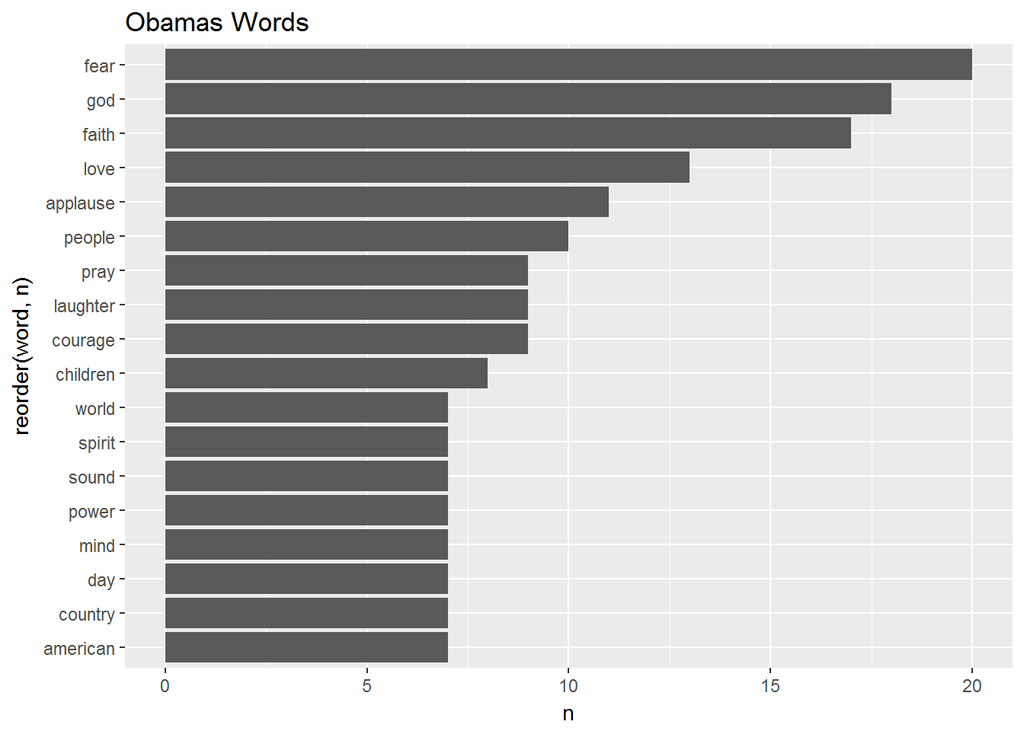

```r
ggplot(tidy4 %>% filter(n >= 7), aes(x=reorder(word, n), y=n)) +geom_col() + coord_flip() + ggtitle("Obamas Words")
```

Now, I want you to do a sentiment analysis for each of these speeches.

Use the “bing” lexicon to do so.

```r
tidy3 <- tidy3 %>% inner_join(get_sentiments("bing"))
tidy3$score <- Recode(tidy3$sentiment, "'positive' =1; 'negative' = -1")

tidy4 <- tidy4 %>% inner_join(get_sentiments("bing"))
tidy4$score <- Recode(tidy4$sentiment, "'positive' =1; 'negative' = -1")

tidy3 %>% mutate(total = n * score) %>% summarise(total = sum(total))
```

```
## # A tibble: 1 × 1
##   total
##   <dbl>
## 1    52
```

```r
tidy4 %>% mutate(total = n * score) %>% summarise(total = sum(total))
```

```
## # A tibble: 1 × 1
##   total
##   <dbl>
## 1    22
```

Which one was more positive? Why do you think that is?